# Практика · Зворотне поширення помилки

# Частина 3 · Навмисна помилка

Тепер найважливіше практичне вміння теми. Зламаємо backprop так, як його ламають найчастіше: **забудемо помножити на похідну активації**. Один зниклий множник.

```python
def зворотний_прохід_із_помилкою(ваги, X, y):
    """Той самий код, але без множення на похідну tanh. Помилка в одному рядку."""
    кеш = прямий_прохід(ваги, X)
    кількість = len(y)

    дельта2 = (кеш["A2"] - y[:, None]) / кількість
    градієнти = {"W2": кеш["A1"].T @ дельта2, "b2": дельта2.sum(axis=0)}

    дельта1 = дельта2 @ ваги["W2"].T
    # ⚠️ ТУТ ПОМИЛКА: пропущено множення на (1 - A1²)

    градієнти["W1"] = X.T @ дельта1
    градієнти["b1"] = дельта1.sum(axis=0)
    return градієнти


зламані = зворотний_прохід_із_помилкою(ваги_з_лекції, ознаки_прикладу, відповідь_прикладу)

print("параметр   правильно      зламано")
for назва in ["W1", "b1", "W2", "b2"]:
    for правильно, зламано in zip(аналітичні[назва].ravel(), зламані[назва].ravel()):
        позначка = "  ← розійшлось" if abs(правильно - зламано) > 1e-9 else ""
        print(f"  {назва:4s}   {правильно: .8f}   {зламано: .8f}{позначка}")
```

```
параметр   правильно      зламано
  W1     -0.46298781   -0.82816122  ← розійшлось
  W1      0.16074910    0.52701169  ← розійшлось
  W1     -0.69448171   -1.24224183  ← розійшлось
  W1      0.24112365    0.79051753  ← розійшлось
  b1      0.46298781    0.82816122  ← розійшлось
  b1     -0.16074910   -0.52701169  ← розійшлось
  W2     -0.49993591   -0.49993591
  W2      0.62763674    0.62763674
  b2     -0.75287384   -0.75287384
```

Око бачить лише те, що якісь числа інші. Але які з них правильні? Без чисельної перевірки відповіді немає. З нею — є, і однозначна.

```python
вектор_зламаний = в_один_вектор(зламані)

похибка_правильного = (np.linalg.norm(вектор_backprop - вектор_чисельний)
                       / (np.linalg.norm(вектор_backprop) + np.linalg.norm(вектор_чисельний)))
похибка_зламаного = (np.linalg.norm(вектор_зламаний - вектор_чисельний)
                     / (np.linalg.norm(вектор_зламаний) + np.linalg.norm(вектор_чисельний)))

print(f"відносна похибка правильного backprop: {похибка_правильного:.2e}")
print(f"відносна похибка зламаного backprop:   {похибка_зламаного:.2e}")
print(f"різниця у {похибка_зламаного / похибка_правильного:.0e} разів")

assert похибка_правильного < 1e-7, "правильний градієнт мав пройти перевірку"
assert похибка_зламаного > 1e-2, "перевірка не помітила помилки — так не буває"
print("\n✅ чисельна перевірка спіймала помилку: 2.8e-01 проти 1.0e-11 — сплутати неможливо")
```

```
відносна похибка правильного backprop: 1.02e-11
відносна похибка зламаного backprop:   2.81e-01
різниця у 3e+10 разів

✅ чисельна перевірка спіймала помилку: 2.8e-01 проти 1.0e-11 — сплутати неможливо
```

## 10 · А тепер найнеприємніше

Зламана мережа **все одно навчається**. Виняток не падає, розміри матриць збігаються, втрата за першу сотню епох падає майже так само, як у правильної. Далі вона тихо повзе вгору — але цей натяк дуже легко списати на завелику швидкість навчання й піти шукати проблему не там. Без чисельної перевірки ти б витратив тиждень на архітектуру й гіперпараметри.

```python
мережа_2 = створити_мережу(2, np.random.default_rng(42))
зламана, історія_зламаної = навчити(мережа_2, X_навч, y_навч, зламаний_градієнт=True)

print("епоха   правильний backprop   зламаний backprop")
for епоха in [0, 100, 500, 1000, 2999]:
    print(f"{епоха:>5}   {історія[епоха]:>17.4f}   {історія_зламаної[епоха]:>17.4f}")

print()
print(f"точність, правильний backprop: {точність(навчена, X_тест, y_тест):.4f}")
print(f"точність, зламаний backprop:   {точність(зламана, X_тест, y_тест):.4f}")
print(f"базова «усі чесні»:            {1 - y_тест.mean():.4f}")
print()
print("Зламана мережа ледве обігнала базову відповідь «усі чесні». Її крива втрат після")
print("сотої епохи повзе вгору — але сама по собі така крива схожа на завелику швидкість навчання.")
```

```
епоха   правильний backprop   зламаний backprop
    0              0.5654              0.5468
  100              0.3383              0.3660
  500              0.3130              0.3744
 1000              0.3087              0.3788
 2999              0.3047              0.3842

точність, правильний backprop: 0.9000
точність, зламаний backprop:   0.8528
базова «усі чесні»:            0.8361

Зламана мережа ледве обігнала базову відповідь «усі чесні». Її крива втрат після
сотої епохи повзе вгору — але сама по собі така крива схожа на завелику швидкість навчання.
```

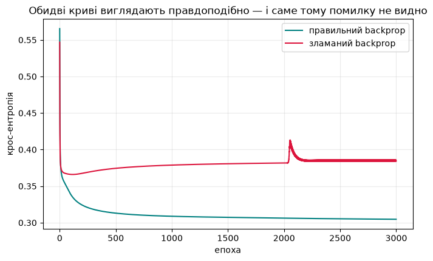

```
Мораль: криву втрат не можна використовувати як доказ правильності градієнта.
```

```python
fig, ax = plt.subplots(figsize=(7, 4.4))
ax.plot(історія, color="teal", label="правильний backprop")
ax.plot(історія_зламаної, color="crimson", label="зламаний backprop")
ax.set_xlabel("епоха"); ax.set_ylabel("крос-ентропія")
ax.set_title("Обидві криві виглядають правдоподібно — і саме тому помилку не видно")
ax.legend(); ax.grid(alpha=.25)
plt.tight_layout(); plt.show()

print("Мораль: криву втрат не можна використовувати як доказ правильності градієнта.")
```

## Завдання

### 🟢 Рівень 1 — База

Поміняй у ручному прикладі ціль з `y = 1` на `y = 0` (тобто вдай, що оголошення чесне) і перерахуй усе заново: прямий прохід, втрату, усі девʼять градієнтів.

**Зроблено, якщо:** втрата стала меншою за 0.3, знак `δ⁽²⁾` змінився на протилежний, а чисельна перевірка так само дала відносну похибку менше `1e-7`.

### 🟡 Рівень 2 — Плюс

Замініть `tanh` у прихованому шарі на ReLU (`np.maximum(0, z)`, похідна — `(z > 0)`). Перепиши `прямий_прохід` і `зворотний_прохід`, прожени чисельну перевірку й навчи мережу на дошці оголошень.

**Зроблено, якщо:** перевірка градієнта пройдена (похибка < `1e-6`), а точність на тестовій вибірці відрізняється від `tanh`-версії менш ніж на 3 відсоткові пункти. Напиши одним реченням, чому для ReLU перевірка може дати гіршу похибку, ніж для `tanh`.

### 🔴 Рівень 3 — Виклик

Додай мережі другий прихований шар: `2 → 4 → 4 → 1`. Перепиши прямий і зворотний проходи так, щоб кількість шарів задавалась списком, а не була зашита в код. Прожени чисельну перевірку на всіх параметрах.

**Зроблено, якщо:** перевірка проходить із відносною похибкою менше `1e-7`, мережа навчається, а ти можеш показати числами, у скільки разів норма градієнта першого шару менша за норму градієнта останнього.